# Coursework Report

*N* removed NAs: 3

*N* removed typo: 1

*N* removed <18: 29

*N* total clean: 117

[output not shown]

**Main analysis results**

[interactive chart not shown]

[figure not shown]

[interactive chart not shown]

# Coursework Report

Analysing Data, Spring 2020

# Methods

## Participants

Table 1 *Descriptive statistics by condition*

| Condition | *N* | % | *M*<sub>age</sub> | *SD*<sub>age</sub> |
| --- | --- | --- | --- | --- |
| control | 56 | 47.9 | 20.9 | 2.23 |
| experimental | 61 | 52.1 | 20.9 | 2.14 |

## Design

The research question of this experiment is ‘do women find men more attractive in conjunction with the colour red?’. Each participant viewed a black and white photo of a man on a red (n=61) or white (n=56) background for 5 seconds and then were asked three questions. These questions were; “How attractive do you think this person is?”, “How pleasant is this person to look at?”, and “If I were to meet the person in this picture face to face, I would think he is attractive.” Attractiveness was rated from 1-9, 1 being ‘not at all attractive’, and 9 being ‘extremely attractive’. These ratings were the dependent variable. The two coloured backgrounds were the independent variables. The experimental condition saw the red background, and the control condition saw the white background.

The photo was 4 inches across and 6 inches tall, and showed the head and upper torso of what was judged to be a moderately attractive, young caucasian man with brown hair wearing a plain button down shirt. The photo was centered on an 8.5 inch wide, and 11-inch tall background, coloured either red or white. White was simply the absence of additional color on the white background already present in the image.

The operational hypothesis for the study is ‘women will rate the man higher in attractiveness score, when viewed with the red background compared to the white background’. A *t*-test will be used to determine the significance of the results in relation to the operational hypothesis.

# Results

The results of the study are shown in this section. Below is a means plot demonstrating the mean composite score for both the experimental and control conditions.

Plot 1 *Means plot of composite score by colour group*

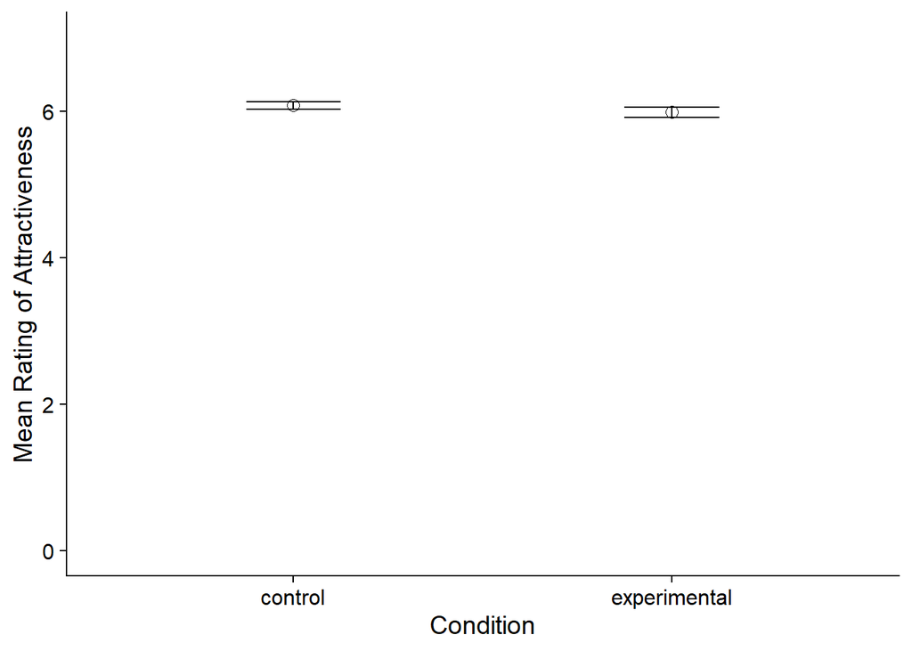

# Discussion

The results from our study show that women do not find men more attractive in conjunction with the colour red. Our research instead found the colour white to lead to higher attractiveness ratings. These findings are contrary to the research by Elliot et al (2010) which this study is based on. Our study does however strengthen the body of evidence that the relationship between red and attractiveness may not be present in humans. For example, research by Peperkoorn, Roberts, and Pollet (2016) presents three studies which all disprove the association between red and attractiveness. They concluded that participants stated the colour of clothing to be an insignificant factor in physical attractiveness. In addition to this Hesslinger, Goldbach, and Carbon (2015) closely replicated the Elliot et al (2010) experiment we also replicated, and found there to be no effect of the colour red on percieved attractiveness.

In addition to contrary evidence, there is also academic critique of the original Elliot et al (2010) study which weakens the claim that there is an association between red and attractiveness in humans. Francis (2013) argued the conclusions of the original Elliot et al (2010) study should rejected, as the research was subject to publication bias. He found the study was conducted in such a way that experiments with non-significant results were not reported, or that the reported experiments were run in a way that the likelihood of rejecting the null hypothesis was inflated. All of this research taken together seems to suggest there is unlikely to be a correlation between the colour red and attractiveness.

The main strength of our study is that it was a highly controlled. As it was conducted in a laboratory setting, our study has high internal validity, and ensures the closest possible replication of Elliot et al’s (2010) original experiment. Furthermore, our study uses data from 117 participants, compared with data from just 21 participants in the original study, further adding to the reliability of our experiment, and the validity of our conclusions.

However, our study is not without its disadvantages. Firstly, as the experiment took place in a laboratory setting, we cannot be sure the same conclusions would be drawn if the experiment were to take place in a natural setting. It may be that an experiment of this type would find red to be linked more strongly to attractiveness, in comparison to other colours. Secondly, in our research we only completed one of the three experiments carried out by Elliot et al (2010). If we had carried out experiments 2 and 3, we may have found evidence to support the claim that women find men more attractive in conjunction with the colour red. Lastly, the experiment only used a photograph of one caucasian male. The ethnicity of the male subject may have influenced how attractive women of different ethnic groups rated him. Furthermore, in our study we did not collect data on the ethnic group of our participants, so we cannot be sure our findings are generalisable to all ethnic groups in society, or whether the absense of a relationship between red and attractiveness is only true of caucasian males.

Considering the evidence, it is unlikely that men are more attractive in conjunction with the colour red, and hence the ‘red effect’ is unlikely to be real. However, future research could focus on trials in natural settings, and use men of different ethnic groups in order to determine whether this effect may be present in the real world, and among different ethnic groups. Research has shown there to be a link between red and attractiveness in the animal kingdom (Elliot et al 2010), and therefore it is possible that this effect is present in humans. A wider variety of research is needed to determine the extent of the effect.

Overall, our study does not support claims by Elliot et al (2010) that women find men more attractive in conjunction with the colour red. At present, research is conflicting and at times inadequate, which makes it difficult to determine whether the ‘red effect’ is a real phenomenon. It is unlikely that colour influences attractiveness to a great extent, however more research is required. Psychologists would need to explore the ‘red effect’ among natural settings and different ethnic groups in order to determine the degree to which this effect exists in humans, if at all.

# References

Elliot, A. J., Niesta-Kayser, D., Greitemeyer, T., Lichtenfeld, S., Gramzow, R. H., et al (2010). “Red, rank, and romance in women viewing men.” *Journal of Experimental Psychology* 139(3): 399-417.

Francis, G. (2013). “Publication bias in ‘Red, rank, and romance, in women viewing men,’ by Elliot et al (2010).” *Journal of Experimental Psychology* 142(1): 292-296.

Hesslinger, V. M., Goldback, L., & Carbon, C. (2015). “Men in red: A reexamination of the red-attractiveness effect.” *Psychonomic Bulletin & Review* 22: 1142-1148.

Peperkoorn, L. S., Roberts, S. C., & Pollet, T. V. (2016). “Revisiting the red effect on attractiveness and sexual receptivity: No effect of the colour red on human mate preferences.” *Evolutionary Psychology* 14(4): 1-13.